# Chapter 7: Review and Practice

# Reminders

- Survey practice 1 is available, but it covers some material we haven’t discussed yet, so you might want to wait before submitting.
- You should have recieved a message about the second GVPT lab experiment.

# Review and Practice

## P-Values and null hypothesis testing

- Step 1: State a null hypothesis and a significance level ($\alpha$)
- Step 2: Assume the null hypothesis is true and ask “What is the probability that random chance would give me a result at least this far away from $H_0$?” (P-value)
- Step 3: If the P-value is less than $\alpha$ you can reject the null.

## Confidence Intervals and null hypothesis testing

- Step 1: State a null hypothesis and a confidence level
- Step 2: Calculate a confidence interval for your estimate, and ask: does a confidence interval at this confidence level contain the null hypothesis?
- Step 3: If the confidence interval doesn’t contain the null hypothesis, you can reject the null.

## A one sample test of proportions

- 76% of respondents (out of 1,316 who answered) in our sample said they voted in the 2024 election.
- In the 2024 election, adult turnout was 59%.
- My null hypothesis is that this is a random sample from the adult population, and so the true population value should be 59%. Can I reject this at the .05 level?

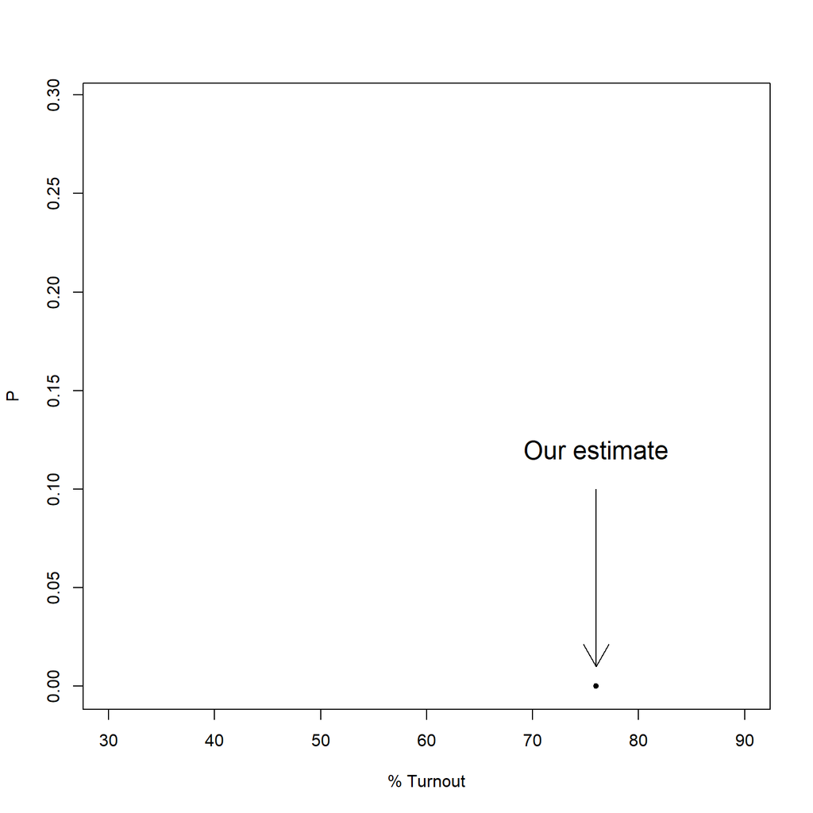

## A one sample test of proportions

- The percent turnout under the null hypothesis is $59\%$
- So, we just want to calculate the probability of being off by $17$ percentage points in either direction.
- $\text{SE} = \sqrt{\frac{76 \times (100-76)}{1316}} \approx 1.2$
- $Z = \frac{17}{1.2} \approx 14.2$

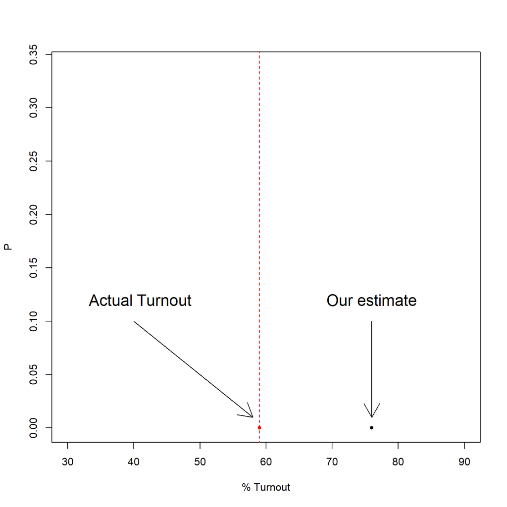

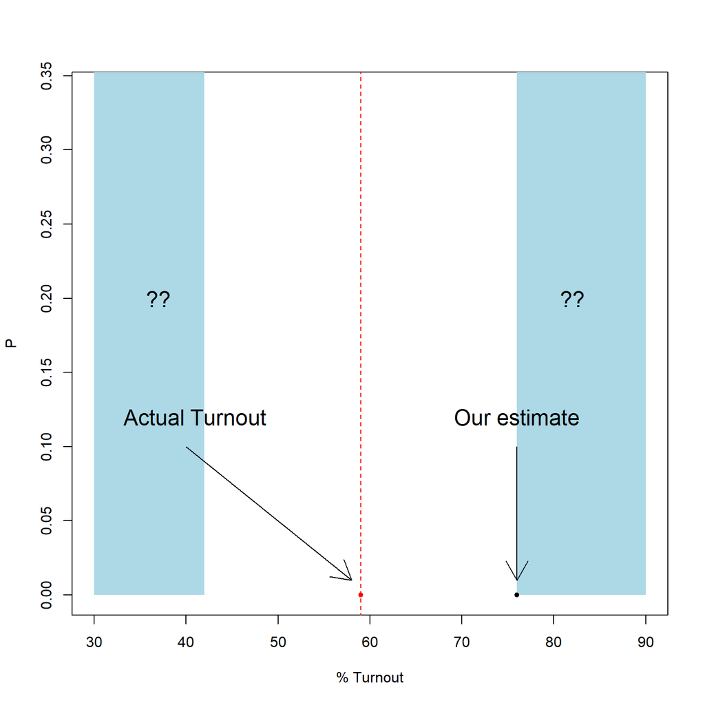

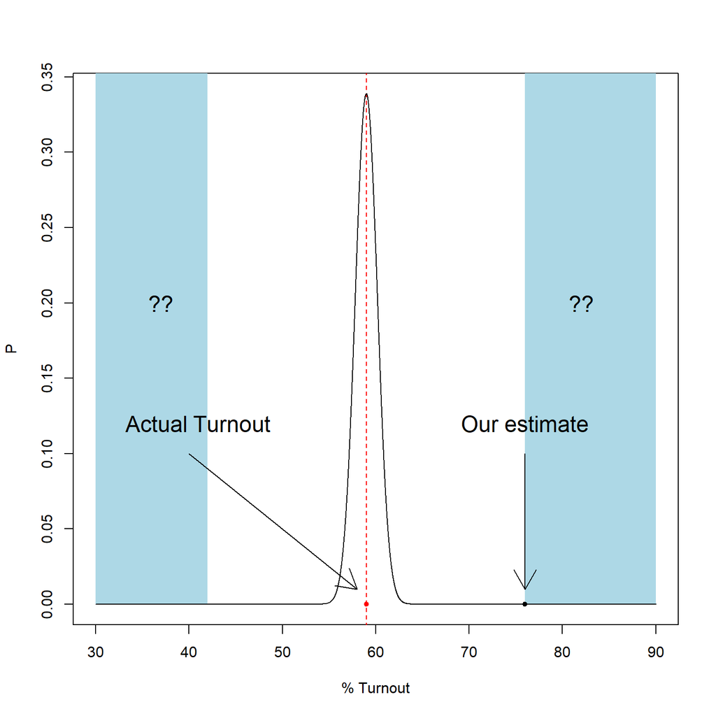

## A one sample test of proportions

```r
testpropsC(x1= survey$voted24, x2 = .59, response='Yes')
```

- What is the probability of seeing a result this extreme if the null is true (look the p-value)?
- Is the result statistically significant at the .05 level?

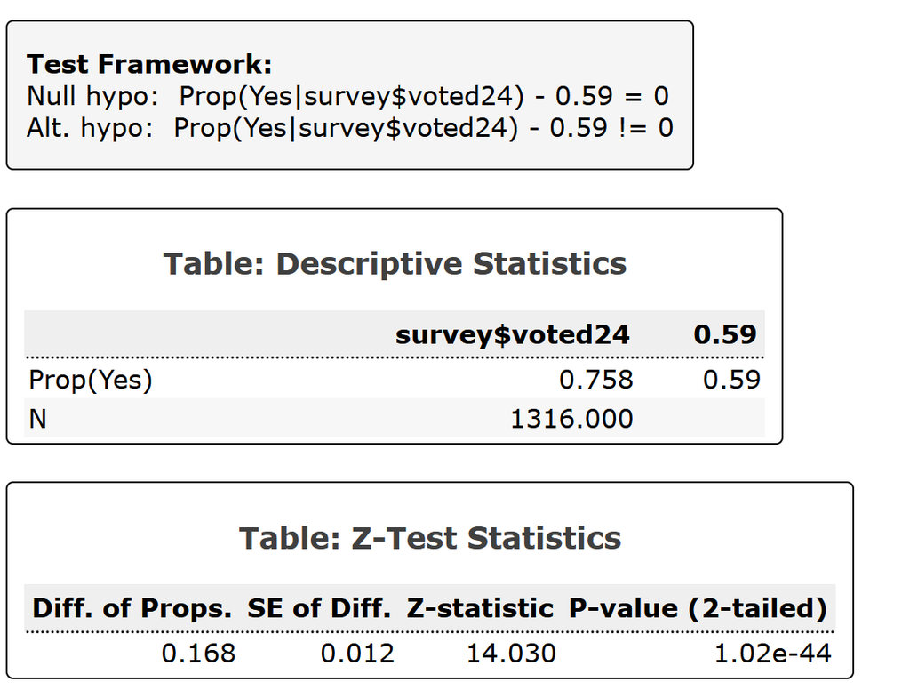

## A one sample test of proportions: confidence interval method

The confidence interval method will give us the same result here. Instead of looking for a p-value less than alpha, we can ask “does the confidence interval for the difference contain zero”?

- .05 significance in a two-tailed test is equivalent to a 95% confidence interval.
- The Z-score associated with a 95% confidence interval is about 1.96
- $.17 \pm 1.96 \times 1.2 \approx [.145, .191]$

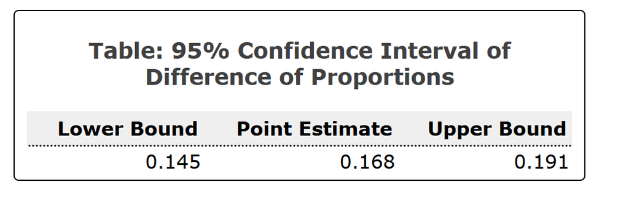

## Sample error

- Why is our sample so different from the population?
- How does this change our interpretation of hypothesis tests?

# Two sample proportions

## Two sample proportions

- Can we rule out the hypothesis that the Inquisition and the Black Plague are equally popular? Is this difference statistically significant at the .05 level?
- $H_0 =$ People are equally favorable towards both (the difference = 0)
- $H_a =$ The Plague and the Inquisition are not equally popular (the difference does not = 0)

## Two sample proportions

- Calculate the observed difference: $0.16 - 0.09 = .07$
- Calculate the standard error of the difference: $\text{SE}_\text{diff}=\sqrt{\frac{.16\times(1-.16)}{2,230} + \frac{0.09 \times (1-0.09)}{2,230}} \approx .01$
- Calculate the Z score: $.07/.01 = 7$

## Two sample proportions

```r
testpropsC(x1 = inquisition, x2=plague, response='favorable', data=yougov_data, printC=TRUE)
```

- What is the probability of seeing a difference at least this large if there is no difference between evaluations of the Plague and the Inquisition?
- Can we reject the null hypothesis at the .05 level?
- What would change here if our hypothesis was that the Inquisition was more popular than the Plague? What if we hypothesized that the Plague was more popular than the Inquisition?

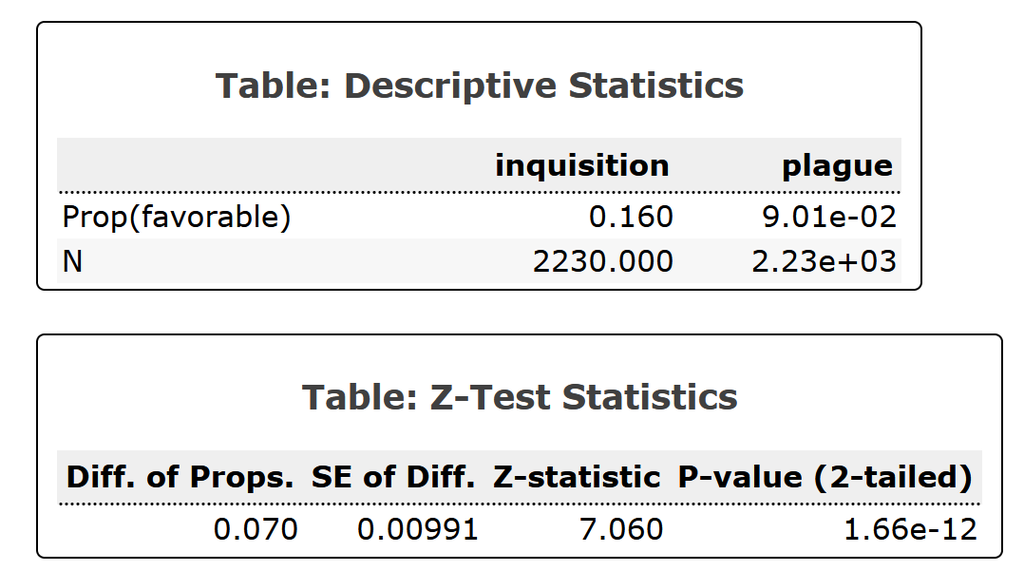

## Two sample proportions: confidence interval method

Again: the confidence interval method will give us the same result here. Instead of looking for a p-value less .05 we can ask “does the 95% confidence interval for the difference contain zero”?

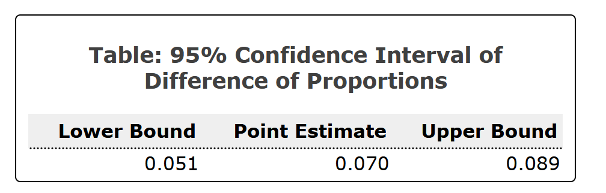

## What to use when

# Cautions about hypothesis testing

## How not to use a p-value

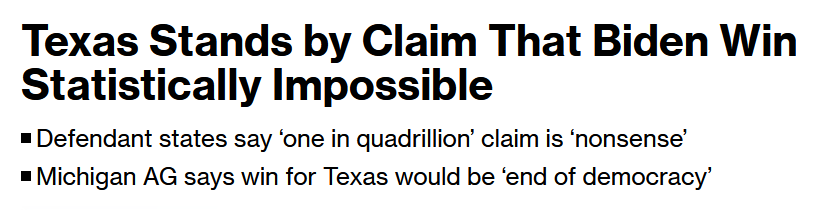

## How not to use a p-value

- Charles Cicchetti, writing in a deposition for the plaintiffs in a lawsuit claiming mass vote fraud swung the 2020 election, used a difference of proportion test to compare Biden’s 2020 results in Georgia to Clinton’s results in the same state.
- The goal was to “test the hypothesis that other things being equal they would have an equal number of votes”

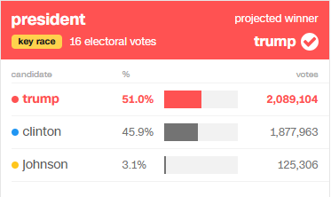

2016 outcome

[figure not shown]

2020 outcome

## How not to use a p-value

Clinton’s 2016 vote $= 45.9\%$ with $4,146,825$ total votes cast

Biden’s 2020 vote $= 49.5\%$ with $4,999,960$ total votes cast

$$\text{diff} = .495 - .459 = .036$$

$$\text{SE}_{\text{diff}} = \sqrt{\frac{.459 \times (1 - .459)}{4146825} + \frac{.495 \times (1-.495)}{4999960}} = 0.000331$$

$$Z = \frac{.036}{0.000331} = 108.7$$

$$P |Z| > z \approx 1 \text{ in } 1,000,000,000,000,000$$

## How not to use a p-value

> “In my opinion, the outcome of Biden winning is so statistically improbable, that it is not possible to dismiss fraud and biased changes in the ways ballots were processed, validated, and tabulated” - Charles Cicchetti

The math checks out! So what’s wrong with this claim?

What is the null hypothesis in this case? What can we conclude from rejecting it?

## How not to use a p-value

> if the objective is to assess whether Biden won legitimately, then it is beside the point whether Biden and Clinton enjoyed the same expected support. Support can differ across candidates for any number of reasons, and it is absurd to think that any such difference constitutes evidence of election fraud. -[Eggers, Garro, and Grimmer](https://www.pnas.org/doi/10.1073/pnas.2103619118)

(the authors go on to note that they can reject this null in every state in every presidential election since 1960)

This tells us that differences across elections aren’t random, but that’s probably not the most important question for researchers!

## What hypothesis testing does

In experimental research, “treatment” is randomly assigned, so once we’ve eliminated “random chance”, we can conclude the difference is due to the treatment.

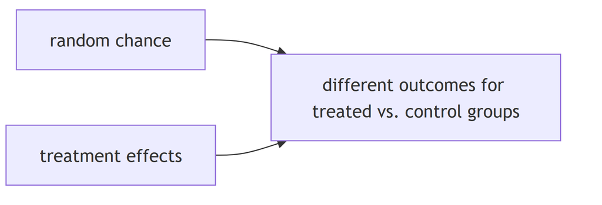

## What hypothesis testing does

- In observational research, ruling out random chance is just the **first step** towards identifying a cause
- We’d need to rule out a lot of other more plausible explanations here first.

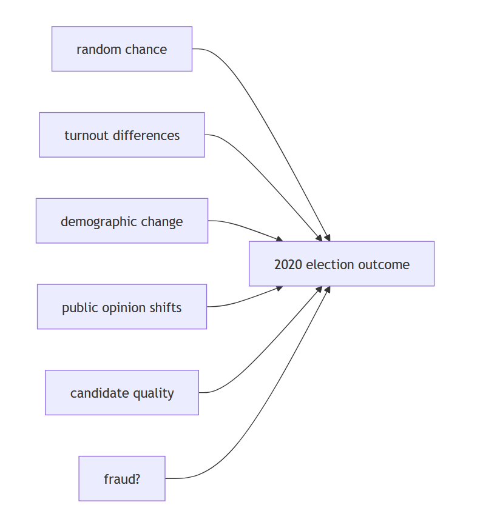

## P-hacking and the “replication crisis”

[figure not shown]

## P-hacking and the “replication crisis”

Lots of causes, but bad hypothesis testing plays a role:

- P < .05 means “1 in 20 results will be a Type I error”
- So, what happens if I just test everything?

## P-hacking and the “replication crisis”

Here’s a function that produces random results, runs a t-test, and then determines whether the results are significant at the .05 level:

```r
set.seed(100)

simulate_experiment<-function(){
  N <- 100
  treatment_assignment<-rep(c("control group", "test group"), each = N/2)
  outcome<-rnorm(length(treatment_assignment))
  p<-t.test(outcome ~ treatment_assignment)$p.value
  significance <- ifelse(p < .05, "significant", "not significant")
  return(significance)
}
```

## P-hacking and the “replication crisis”

If I run this function 100 times, I’ll get about 5 significant results:

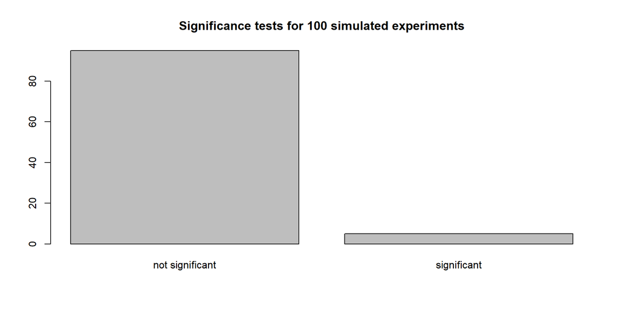

```r
p_values<-replicate(n=100, expr = simulate_experiment())
barplot(table(p_values), main = "Significance tests for 100 simulated experiments")
```

but there’s definitely not a relationship here. This is random noise!

## P-hacking and the “replication crisis”

- The ANES has thousands of variables, so there are bound to be hundreds of combinations that will give us significant results purely by chance.
- P-hacking, or trying out a bunch of models until one just gets over the threshold for significance, is bound to produce false positives.

## P-hacking and the “replication crisis”

- In published research, there are few incentives to publish a non-significant result, so people sometimes run lots of tests and only publish the ones that “work”
- Which results in lots of findings that later can’t be replicated: they were just random false positives.

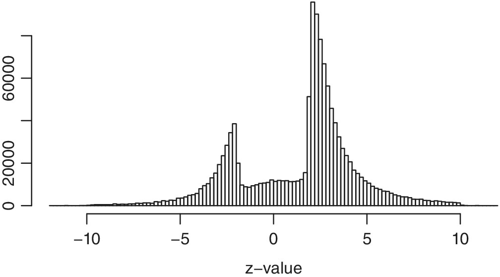

Z-values in pubished papers in medical research from: van Zwet, Erik W., and Eric A. Cator. “The significance filter, the winner’s curse and the need to shrink.” Statistica Neerlandica 75.4 (2021): 437-452.

## Best practices

- Exploring your data is fine (especially when you’re learning) but running more tests means you should be more skeptical of your results.
- As a reader, you should be cautious when you see a result that just barely meets the criteria for significance, especially if its:
  - Not supported by additional replications or the hypothesis wasn’t pre-registered
  - Un-intuitive or not based on some pre-existing theory or reasonable expectation
  - Substantively small and/or based on a small sample

# Difference of Two Means

- People who did not self-ID as male were about .68 points less positive in their views of the direction of the country.
- What’s the probability of seeing a difference at least this large if the actual difference is zero? Can we dismiss the null hypothesis at the .05 level here?

| question | **not male** n = 796 | **male** n = 498 |
| --- | --- | --- |
| How would you rate the current state of affairs in the United States? (0 = wrong track, 10 = right direction) | 1.95 (2.33) | 2.63 (2.57) |

Note:  
Mean (SD)

## Difference of Two Means

- $\text{diff} = -.68$
- $\text{SE}_\text{diff} = \sqrt{\frac{2.33^2}{796} + \frac{2.57^2}{498}} \approx{0.142}$
- $\text{T} = \frac{.68}{0.142} = 4.8$
- (The T distribution is going to be very similar to a Z distribution because our N is over 30.)

| question | **not male** n = 796 | **male** n = 498 |
| --- | --- | --- |
| How would you rate the current state of affairs in the United States? (0 = wrong track, 10 = right direction) | 1.95 (2.33) | 2.63 (2.57) |

Note:  
Mean (SD)

## Difference of Two Means

```r
testmeansC(iv = binary_gender, dv = wrong_or_right_track, data=survey, printC=TRUE)
```

[output not shown]